# 03-introduction-to-seaborn slides

## Start Jupyter notebook on Nova on demand.

You can start Jupyter notebook on Nova on demand. This will allow you to run Jupyter notebook on the server and access it from your local machine.

1. Go to the [Nova OnDemand](https://nova-ondemand.its.iastate.edu/) and login
2. Under the "Interactive Apps" tab, click on "Jupyter Notebook", request desired resources and click "Launch"
3. Wait for the job to start and click on the "Connect to Jupyter" button

## Plotting and Visualization

Visualization is a key component of data analysis, allowing you to explore data and communicate results. We have briefly touched on visualization. Now we will go over the basics in more depth. There are two libraries that are commonly used for plotting. **Matplotlib** is the most popular Python library for creating static, animated, and interactive visualizations in Python. **Seaborn** builds on Matplotlib, allowing us to create more attractive and statistically meaningful graphs with better defaults and built-in support for complex relationships. So, although we are learning about Seaborn, we will still use Pandas to load and manipulate the data, `matplotlib` for additional customization, and `seaborn` for plotting.

# Getting Started

To begin, we need to import the necessary libraries. We want Pandas to manipulate the dataframes, and matplotlib to provide us extended plot functionality. Then we also load seaborn so that we can make pretty plots. Just like pandas was abbreviated on import (`pd`), common conventions apply for seaborn and matplotlib

```python
import pandas as pd
import seaborn as sns
import matplotlib.pyplot as plt
```

First, we will set change some default settings to our specification (and make the plots look better!). Let's increase the resolution (dpi) to 200, increase the size to 10 x 5 inches, and decrease the font to 8 points (squeeze more characters in!).

```python
plt.rcParams['figure.dpi'] = 200
plt.rcParams['figure.figsize'] = 10,5
plt.rcParams.update({'font.size': 8})
```

## Load the data

Seaborn comes with built-in datasets that you can use to test the library. To check the available datasets, you can use `sns.get_dataset_names()`

```python
sns.get_dataset_names()
```

```
['anagrams',
 'anscombe',
 'attention',
 'brain_networks',
 'car_crashes',
 'diamonds',
 'dots',
 'dowjones',
 'exercise',
 'flights',
 'fmri',
 'geyser',
 'glue',
 'healthexp',
 'iris',
 'mpg',
 'penguins',
 'planets',
 'seaice',
 'taxis',
 'tips',
 'titanic']
```

The dataset `iris` is a commonly used example in data transformation and visualization, so we will load that.

```python
iris = sns.load_dataset('iris')
iris
```

|  | sepal_length | sepal_width | petal_length | petal_width | species |
| --- | --- | --- | --- | --- | --- |
| 0 | 5.1 | 3.5 | 1.4 | 0.2 | setosa |
| 1 | 4.9 | 3.0 | 1.4 | 0.2 | setosa |
| 2 | 4.7 | 3.2 | 1.3 | 0.2 | setosa |
| 3 | 4.6 | 3.1 | 1.5 | 0.2 | setosa |
| 4 | 5.0 | 3.6 | 1.4 | 0.2 | setosa |
| ... | ... | ... | ... | ... | ... |
| 145 | 6.7 | 3.0 | 5.2 | 2.3 | virginica |
| 146 | 6.3 | 2.5 | 5.0 | 1.9 | virginica |
| 147 | 6.5 | 3.0 | 5.2 | 2.0 | virginica |
| 148 | 6.2 | 3.4 | 5.4 | 2.3 | virginica |
| 149 | 5.9 | 3.0 | 5.1 | 1.8 | virginica |

150 rows × 5 columns

We will also load some other datasets for the exercises to showcase different seaborn functions.

```python
titanic = sns.load_dataset('titanic')
titanic.head()
```

|  | survived | pclass | sex | age | sibsp | parch | fare | embarked | class | who | adult_male | deck | embark_town | alive | alone |
| --- | --- | --- | --- | --- | --- | --- | --- | --- | --- | --- | --- | --- | --- | --- | --- |
| 0 | 0 | 3 | male | 22.0 | 1 | 0 | 7.2500 | S | Third | man | True | NaN | Southampton | no | False |
| 1 | 1 | 1 | female | 38.0 | 1 | 0 | 71.2833 | C | First | woman | False | C | Cherbourg | yes | False |
| 2 | 1 | 3 | female | 26.0 | 0 | 0 | 7.9250 | S | Third | woman | False | NaN | Southampton | yes | True |
| 3 | 1 | 1 | female | 35.0 | 1 | 0 | 53.1000 | S | First | woman | False | C | Southampton | yes | False |
| 4 | 0 | 3 | male | 35.0 | 0 | 0 | 8.0500 | S | Third | man | True | NaN | Southampton | no | True |

```python
tips = sns.load_dataset('tips')
tips.head()
```

|  | total_bill | tip | sex | smoker | day | time | size |
| --- | --- | --- | --- | --- | --- | --- | --- |
| 0 | 16.99 | 1.01 | Female | No | Sun | Dinner | 2 |
| 1 | 10.34 | 1.66 | Male | No | Sun | Dinner | 3 |
| 2 | 21.01 | 3.50 | Male | No | Sun | Dinner | 3 |
| 3 | 23.68 | 3.31 | Male | No | Sun | Dinner | 2 |
| 4 | 24.59 | 3.61 | Female | No | Sun | Dinner | 4 |

## Basic plotting

Let's first begin by creating a scatterplot from the iris data. In addition to specifying which columns belong to the x and y axes, we also want to color the data by species.

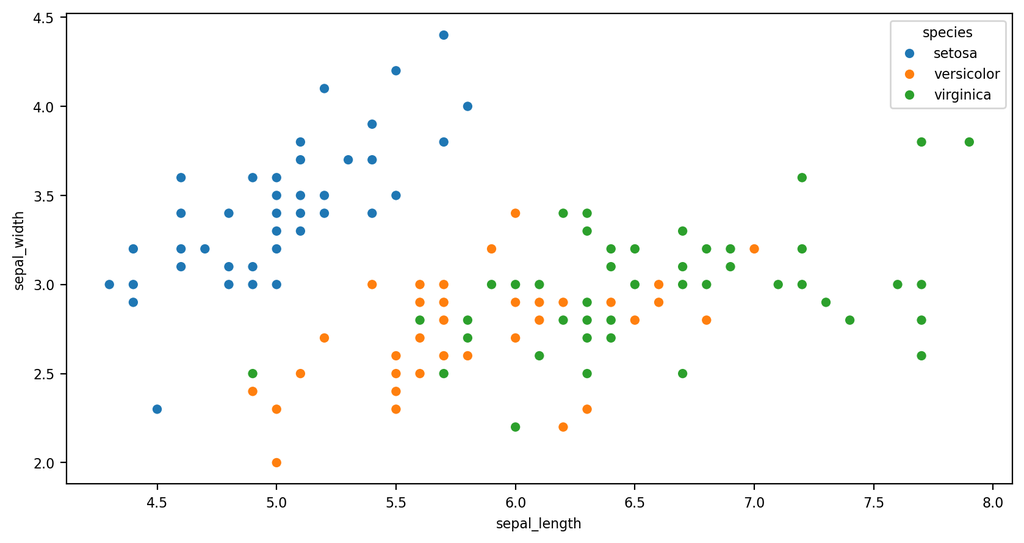

```python
sns.scatterplot(data=iris, x='sepal_length', y='sepal_width', hue='species');
```

We can also create boxplot of the data

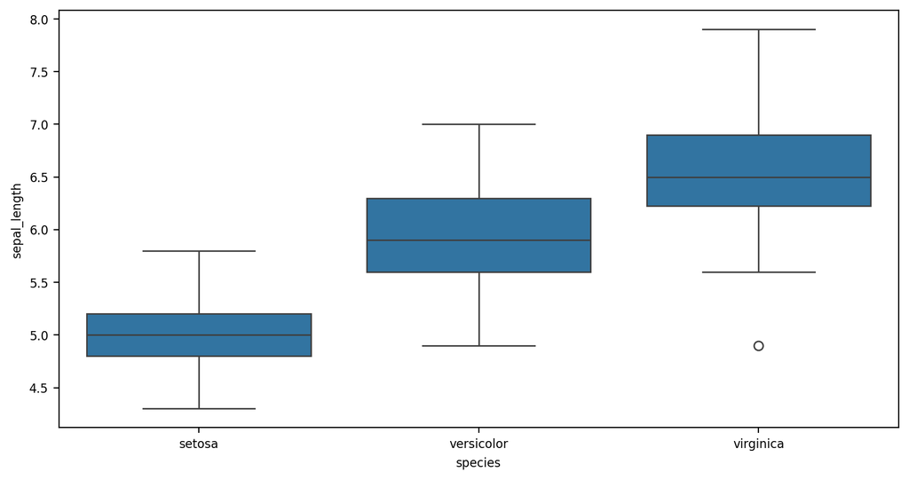

```python
sns.boxplot(data=iris, x='species', y='sepal_length');
```

## Violin plot of the iris dataset

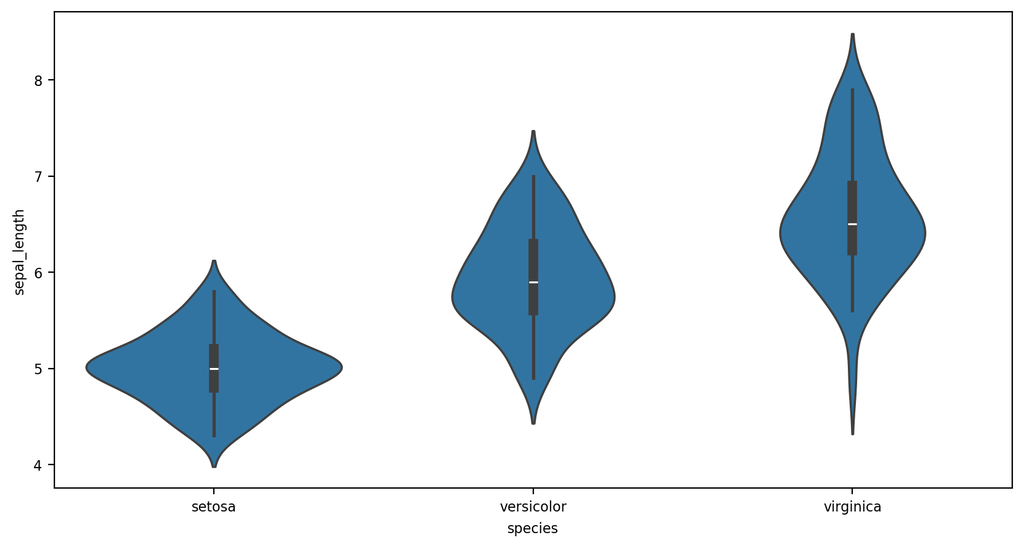

```python
sns.violinplot(data=iris, x='species', y='sepal_length');
```

## Data exploration

Now we will explore the titanic dataset to understand the relationship between the variables. Let's check out the data first.

```python
titanic.head()
```

|  | survived | pclass | sex | age | sibsp | parch | fare | embarked | class | who | adult_male | deck | embark_town | alive | alone |
| --- | --- | --- | --- | --- | --- | --- | --- | --- | --- | --- | --- | --- | --- | --- | --- |
| 0 | 0 | 3 | male | 22.0 | 1 | 0 | 7.2500 | S | Third | man | True | NaN | Southampton | no | False |
| 1 | 1 | 1 | female | 38.0 | 1 | 0 | 71.2833 | C | First | woman | False | C | Cherbourg | yes | False |
| 2 | 1 | 3 | female | 26.0 | 0 | 0 | 7.9250 | S | Third | woman | False | NaN | Southampton | yes | True |
| 3 | 1 | 1 | female | 35.0 | 1 | 0 | 53.1000 | S | First | woman | False | C | Southampton | yes | False |
| 4 | 0 | 3 | male | 35.0 | 0 | 0 | 8.0500 | S | Third | man | True | NaN | Southampton | no | True |

```python
titanic.info()
```

```
<class 'pandas.core.frame.DataFrame'>
RangeIndex: 891 entries, 0 to 890
Data columns (total 15 columns):
 #   Column       Non-Null Count  Dtype
---  ------       --------------  -----
 0   survived     891 non-null    int64
 1   pclass       891 non-null    int64
 2   sex          891 non-null    object
 3   age          714 non-null    float64
 4   sibsp        891 non-null    int64
 5   parch        891 non-null    int64
 6   fare         891 non-null    float64
 7   embarked     889 non-null    object
 8   class        891 non-null    category
 9   who          891 non-null    object
 10  adult_male   891 non-null    bool
 11  deck         203 non-null    category
 12  embark_town  889 non-null    object
 13  alive        891 non-null    object
 14  alone        891 non-null    bool
dtypes: bool(2), category(2), float64(2), int64(4), object(5)
memory usage: 80.7+ KB
```

This dataset contains information of all the passengers aboard the RMS Titanic, including some demographic and survival data. First, let's check the number of passengers in each class.

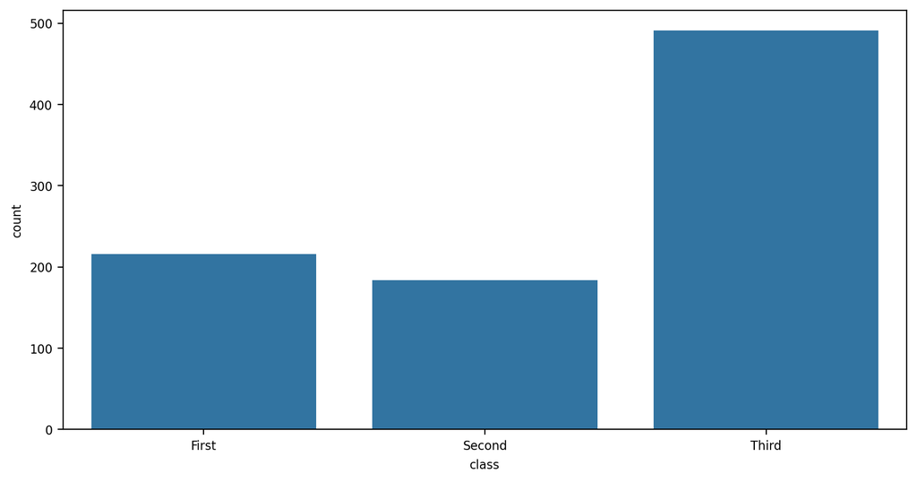

```python
sns.countplot(data=titanic, x='class');
```

We can plot these classes by survival:

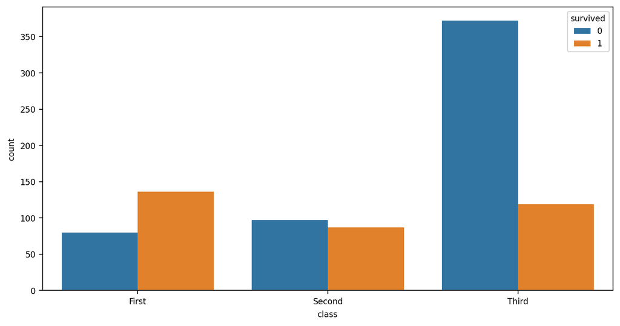

```python
sns.countplot(data=titanic, x='class', hue='survived');
```

Alternatively, we can group survival by sex instead of class.

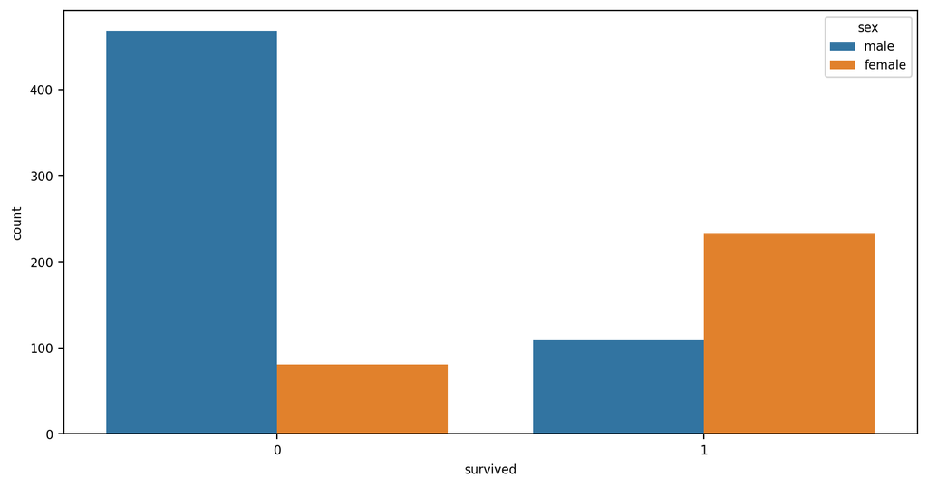

```python
sns.countplot(data=titanic, x='survived', hue='sex');
```

We can check this information for other variables as well. Here we can see survival by where they embarked (perhaps a proxy for class?).

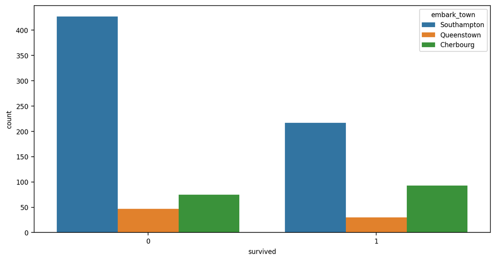

```python
sns.countplot(data=titanic, x='survived', hue='embark_town');
```

If we want to see overall survival rate, we can plot the data without any groups (*i.e.*, `hue`)

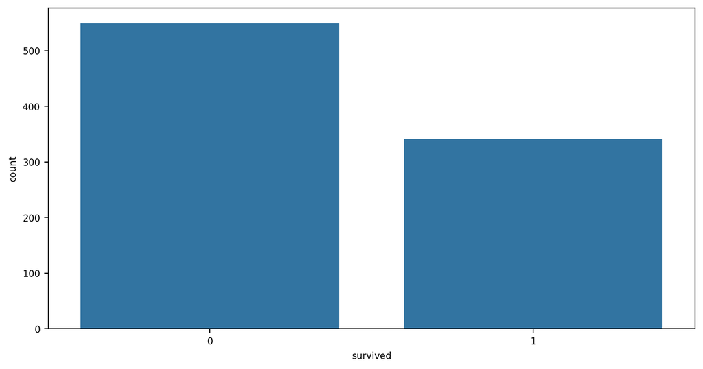

```python
sns.countplot(x='survived', data=titanic);
```

Other informational plots can be created using the `sns.catplot` function. (Here, `catplot` is generic way of saying this is a categorical plot. Other categorical plots include:

- *strip*: A scatter plot where one of the variables is categorical.
- *swarm*: Similar to strip plots but with adjustments to avoid overlapping points.
- *box*: Box plots that display the distribution of data.
- *violin*: Violin plots that combine a box plot with a kernel density estimate.
- *bar*: Bar plots summarizing the central tendency of the data.
- *point*: Point plots to show estimated values and their confidence intervals.

If you don't remember the shorthand for it (*i.e.*, `.boxplot()`), you can always use the `kind` command within catplot. Here we will make a boxplot with fare on the y-axis (instead of count) and we will use `sns.catplot(kind="box")` to make our boxplot.

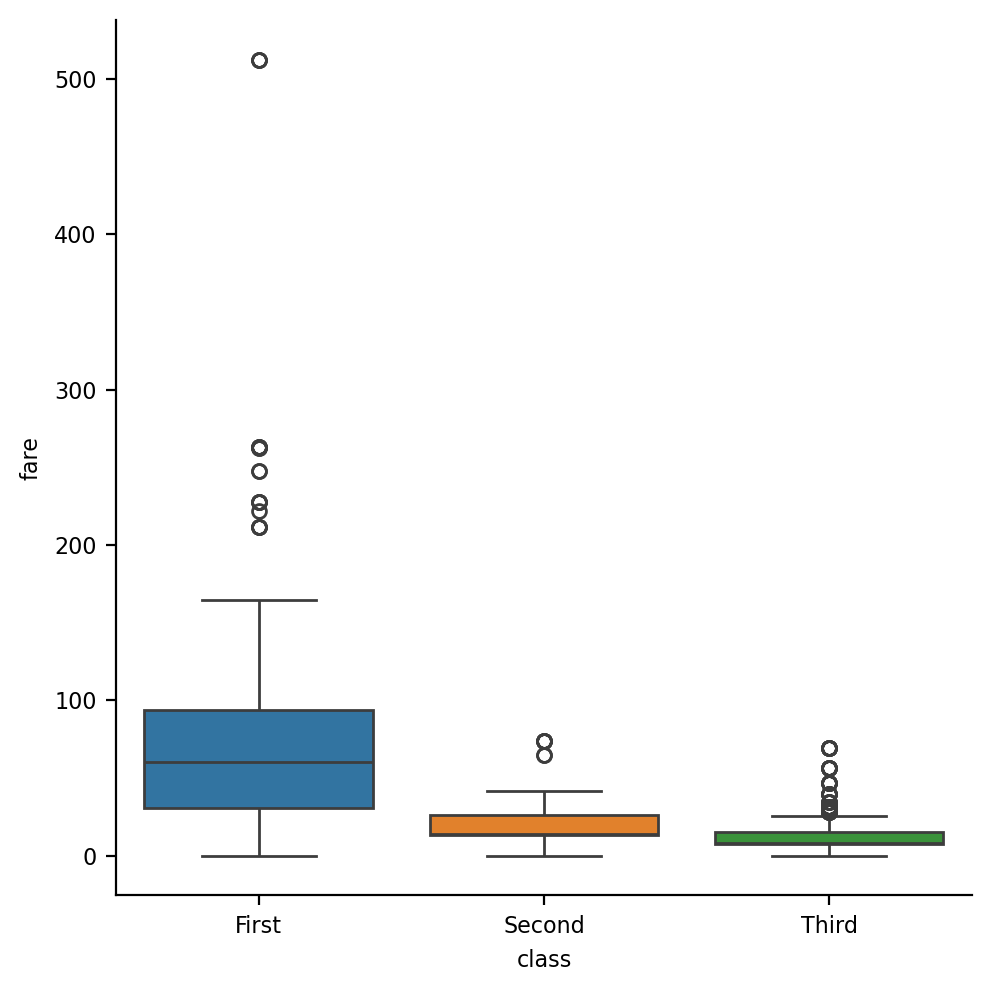

```python
sns.catplot(data=titanic, x='class', y='fare', hue = 'class', kind='box');
```

Seaborn can easily make more complicated plots. For example, we can easily make a *pairplot*, which generates scatter plots for all pairwise combinations of numerical features and places them with density plots (on the diagonal). We will use the iris dataset to demonstrate this since it is small.

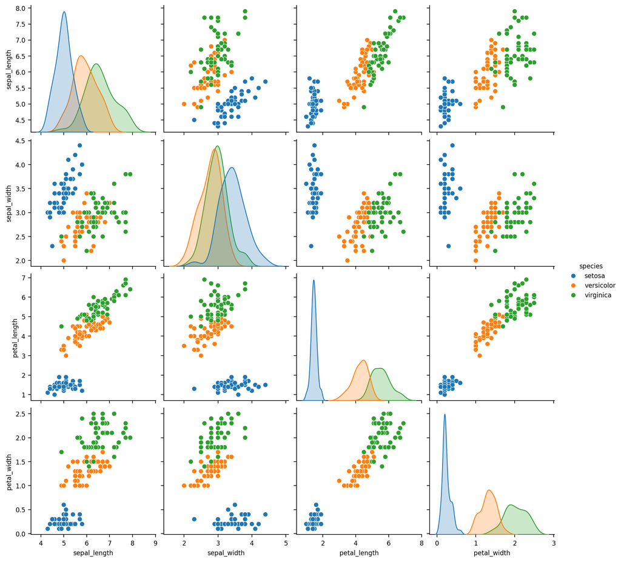

```python
sns.pairplot(iris, hue='species');
```

Seaborn has different plot types: relational plots, distribution plots, and categorical plots.

[figure not shown]

Because our earlier plots were all one type (and subtype), we were easily able to plot our data. If, however, we want to combine plots of difference types, we will have to make panels for each of the plots using a combination of `plt` and `sns`. Here we will combine a scatterplot and a boxplot in the same figure.

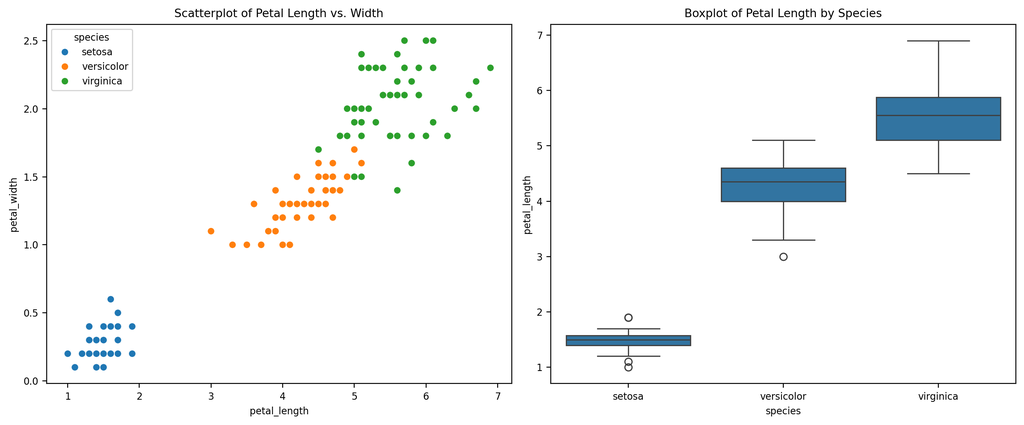

```python
fig, axes = plt.subplots(1, 2, figsize=(12, 5))  # define a figure with 2 axes arrayed as 1 row, 2 columns

# Scatterplot on the first subplot
sns.scatterplot(data=iris, x="petal_length", y="petal_width", hue="species", ax=axes[0])
axes[0].set_title("Scatterplot of Petal Length vs. Width")

# Boxplot on the second subplot
sns.boxplot(data=iris, x="species", y="petal_length", ax=axes[1])
axes[1].set_title("Boxplot of Petal Length by Species")

# Show the plots
plt.tight_layout()
plt.show()
```

Compare that to the minimal code required for a single type of plot, but split into facets.

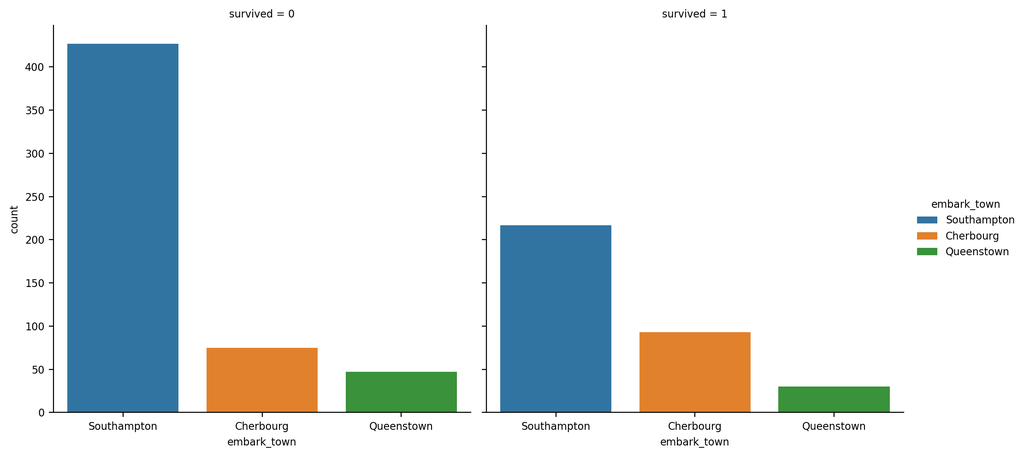

```python
sns.catplot(x="embark_town", col="survived", data=titanic, kind="count", hue="embark_town")
```

You can learn more about seaborn plot types at the seaborn website. Next time, we will discuss practical uses for seaborn and see some more sophisticated uses